## Computer Science Department

### ENGR 202: Data Science and Artificial Intelligence- Spring 2024

# Lab4: Data Preperation for Machines Learning Algorithms

### Aim:

```
To Analayze/visualize dataset and prepare it for Machines Learning Algorithms
```

### Objectives:

- Discover and Visualize the Data to Gain Insights
- Data Cleaning
- Handling Text and Categorical Attributesand
- features scaling.

#### Risk Assessment: Low

# Introducion:

When you are learning about Machine Learning it is best to actually experiment with real-world data. You can always find good samples in many websites such as [Kaggle Datasets](https://www.kaggle.com/datasets) for your learning. For this Lab and the coming lab, we chose the **California Housing Prices dataset** from the StatLib repository2. This dataset was based on data from the 1990 California census. It is not exactly recent but we will use it as if it is recent data.

Welcome to Machine Learning Housing Corporation! The first task you are asked to perform is to build a model of housing prices in California using the California census data. This data has metrics that has been collected for each block group in California. Block groups are the smallest geographical unit for which the US Census Bureau publishes sample data (a block group typically has a population of 600 to 3,000 people). We will just call them “districts” for short. The metrics included in this dataset are:

- longitude: geographical Longitude for the district.
- latitude:geographical Latitude for the district.
- housing_median_age: the median age for the houses in the district.
- total_rooms: total number of rooms in the houses in the district.
- total_bedrooms:total number of rooms in the houses in the district.
- population: number of people in the district.
- households: number of households in all the houses in the district.
- median_income: the median of the houses annual income in 10000$.
- ocean_proximity: how far the district from the ocean.
- median_house_value: median price for the houses in the district.

Your model should learn from this data and be able to predict the median housing price in any district, given all the other metrics. So we will first have data exploration and visualization to gain insight. Then, we will preprocess the data to prepare it for machines learning. Designing, testing and evaluating the model will be conducted in lab5.

# Part1: Data Exploration and Visualization:

We need to explore the data before we prepare it for Machine learning algorithms. So, we will look at the data structures we have. Then, we will get deeper insights into the data and study the correlations between the features and the target (What we want the machine to predict). We will need to reprocess the text/categorical attributes, if any before studying the correlations.

## Step1: Study the data structues of the dataset

**Q1. Read housing data stored in a file called "housing.csv" using using **Pandas** library as you learned last lab.**

```python
# TODO: Import pandas
import pandas as pd
# TODO: Read The csv file.
df = pd.read_csv('housing.csv')
```

**Q2. show head of your dataframe "housing"**

```python
# TODO: Use head to show a quick brief of the dataset.
df.head()
```

|  | longitude | latitude | housing_median_age | total_rooms | total_bedrooms | population | households | median_income | median_house_value | ocean_proximity |
| --- | --- | --- | --- | --- | --- | --- | --- | --- | --- | --- |
| 0 | -122.23 | 37.88 | 41.0 | 880.0 | 129.0 | 322.0 | 126.0 | 8.3252 | 452600.0 | NEAR BAY |
| 1 | -122.22 | 37.86 | 21.0 | 7099.0 | 1106.0 | 2401.0 | 1138.0 | 8.3014 | 358500.0 | NEAR BAY |
| 2 | -122.24 | 37.85 | 52.0 | 1467.0 | 190.0 | 496.0 | 177.0 | 7.2574 | 352100.0 | NEAR BAY |
| 3 | -122.25 | 37.85 | 52.0 | 1274.0 | 235.0 | 558.0 | 219.0 | 5.6431 | 341300.0 | NEAR BAY |
| 4 | -122.25 | 37.85 | 52.0 | 1627.0 | 280.0 | 565.0 | 259.0 | 3.8462 | 342200.0 | NEAR BAY |

**Q3. Use .info() function to explore some information about the dataset.**

The .info() method is useful to get a quick description of the data, in particular the total number of rows, and each attribute’s type and number of non-null values

```python
df.info()
```

```
<class 'pandas.core.frame.DataFrame'>
RangeIndex: 20640 entries, 0 to 20639
Data columns (total 10 columns):
 #   Column              Non-Null Count  Dtype
---  ------              --------------  -----
 0   longitude           20640 non-null  float64
 1   latitude            20640 non-null  float64
 2   housing_median_age  20640 non-null  float64
 3   total_rooms         20640 non-null  float64
 4   total_bedrooms      20433 non-null  float64
 5   population          20640 non-null  float64
 6   households          20640 non-null  float64
 7   median_income       20640 non-null  float64
 8   median_house_value  20640 non-null  float64
 9   ocean_proximity     20640 non-null  object
dtypes: float64(9), object(1)
memory usage: 1.6+ MB
```

The `.info()` method displays the number of non-empty cells in each column. If the column has no empty value, the total count should equal the number of records you have in the dataset. You may have noticed that all columns has the same number of rows except **total_bedrooms** column. Based on that, **Q4: What does that mean when the count of `total_bedrooms` is different than the count of the other columns?**

**Q5: How many rows does the dataset has?**

```python
# #TODO: write your code here
print(df.shape[0])
```

```
20640
```

**Q6. How many null cells in the `total_bedrooms` column?** (Write a python code to compute it.)

```python
# TODO: Get the total number of rows in the dataset (Same code you did in Q5)
total_rows_count = df.shape[0]

# TOD0: Get the total non-empty cells of the total bedroom from the `count()` method.
total_non_null_cells = df['total_bedrooms'].count()

# TODO: Compute the total empty cells
null_cells_count = total_rows_count - total_non_null_cells

# TODO: Print the number of null cells.
print(null_cells_count)
```

```
207
```

**Q7.which attribute is categorical attribute? What its datatype?** (Write your answer in a markdown format)

ocean_proximity columns

**Q8.find the different categories of the "ocean proximity" using value_counts() method**

```python
df['ocean_proximity'].value_counts()
```

```
ocean_proximity
<1H OCEAN     9136
INLAND        6551
NEAR OCEAN    2658
NEAR BAY      2290
ISLAND           5
Name: count, dtype: int64
```

**Q8.Show a summery of the housing statistics using .describe() method.**

```python
df.describe()
```

|  | longitude | latitude | housing_median_age | total_rooms | total_bedrooms | population | households | median_income | median_house_value |
| --- | --- | --- | --- | --- | --- | --- | --- | --- | --- |
| count | 20640.000000 | 20640.000000 | 20640.000000 | 20640.000000 | 20433.000000 | 20640.000000 | 20640.000000 | 20640.000000 | 20640.000000 |
| mean | -119.569704 | 35.631861 | 28.639486 | 2635.763081 | 537.870553 | 1425.476744 | 499.539680 | 3.870671 | 206855.816909 |
| std | 2.003532 | 2.135952 | 12.585558 | 2181.615252 | 421.385070 | 1132.462122 | 382.329753 | 1.899822 | 115395.615874 |
| min | -124.350000 | 32.540000 | 1.000000 | 2.000000 | 1.000000 | 3.000000 | 1.000000 | 0.499900 | 14999.000000 |
| 25% | -121.800000 | 33.930000 | 18.000000 | 1447.750000 | 296.000000 | 787.000000 | 280.000000 | 2.563400 | 119600.000000 |
| 50% | -118.490000 | 34.260000 | 29.000000 | 2127.000000 | 435.000000 | 1166.000000 | 409.000000 | 3.534800 | 179700.000000 |
| 75% | -118.010000 | 37.710000 | 37.000000 | 3148.000000 | 647.000000 | 1725.000000 | 605.000000 | 4.743250 | 264725.000000 |
| max | -114.310000 | 41.950000 | 52.000000 | 39320.000000 | 6445.000000 | 35682.000000 | 6082.000000 | 15.000100 | 500001.000000 |

**Q9.Plot a histogram for all the numerical attributes**

use: housing.hist(bins=50, figsize=(20,15)) after importing matplotlib.pyplot

```
array([[<Axes: title={'center': 'longitude'}>,
        <Axes: title={'center': 'latitude'}>,
        <Axes: title={'center': 'housing_median_age'}>],
       [<Axes: title={'center': 'total_rooms'}>,
        <Axes: title={'center': 'total_bedrooms'}>,
        <Axes: title={'center': 'population'}>],
       [<Axes: title={'center': 'households'}>,
        <Axes: title={'center': 'median_income'}>,
        <Axes: title={'center': 'median_house_value'}>]], dtype=object)
```

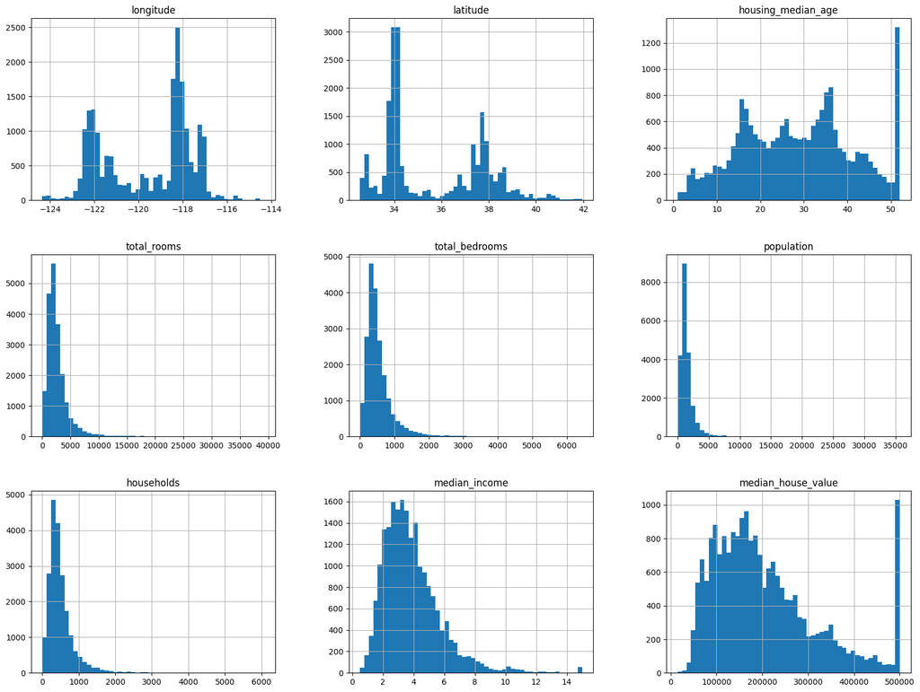

```python
import matplotlib.pyplot as plt
df.hist(bins=50, figsize=(20,15))
```

As you may notice, all distributions of the data present an almost constant shape except for columns `median_house_value` and `housing_median_age`. Although the data still have a consistent shape, the highest value in each has a relatively high frequency! This process is called the data cap. Despite that, the data cap assists in handling the distribution of values of relatively small frequencies; it could cause a significant problem when it is not managed properly.

**Q10. The `housing median age` and the `median house value` were capped to the values shown. Thus, you have two parts (Normal data + capped data), as shown in the graph; which one do you think has more impact on your machine learning algorithms in the training process? Why?**

As mentioned having a capped values can having a negative impact on the model performance if not manages properly. However, these columns plays a major role in the model as they are important to determine the house value

## Step 2: Data Interperation though visualization

The dataset represents description of some house prices at certain region. As you might expect, the price can differ based on the price location. At this part, you will visualize a geographical representation of the houses with respect to the ocean. As you have noticed earlier, there is a column called `ocean_proximity` that indicates whether a house is close or far from the ocean.

```
Output from Q8
ocean_proximity
<1H OCEAN     9136
INLAND        6551
NEAR OCEAN    2658
NEAR BAY      2290
ISLAND           5
```

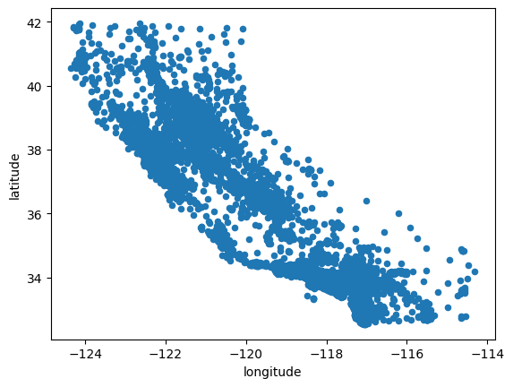

```python
df.plot(kind="scatter", x="longitude", y="latitude")
```

**Q16. Look at calefornia map in a geographical map and comment on the graph above.**

we can see that most of the houses are located in the main cities (San Jose, Los Angeles). we can also see that the number of the houses decrease as we go far from the ocean.

We can add some arguments to the plot function above to show more inoformation that shows cobined attribute in a very informative way. Here we are using a color map to display the median_house_value in color that goes as in the legend. also it showes the population as the diameter of the circle.

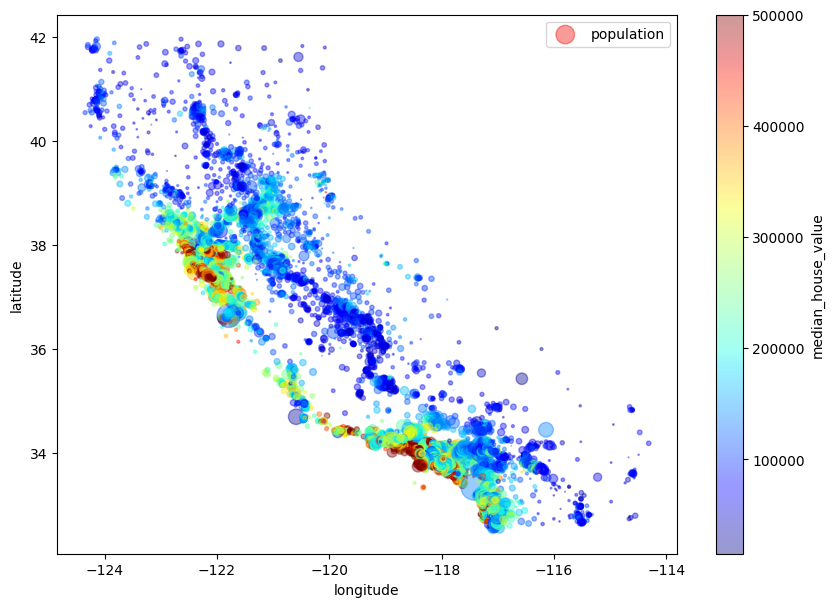

```python
df.plot(kind="scatter", x="longitude", y="latitude", alpha=0.4,
             s=df["population"]/100, label="population", figsize=(10,7),
             c="median_house_value", cmap=plt.get_cmap("jet"), colorbar=True,
             sharex=False)
plt.legend()
```

**Q17. What are your observations about the relation between the housing prices and the location of hte housing?**

As expected the houses near to the ocean are often more expensive than the houses far from the ocean

## Step3: Looking for Correlations

**Q18. Find the correlation matrix of all featues and sort only correlation with the median_house_value**

```python
#uncomment the code below:
corr_matrix=df.corr()
corr_matrix["median_house_value"].sort_values(ascending=False)
```

[output not shown]

The error is because we have categorical feature; "Ocean proximity".

**Q19. Copy the code above and modify it below to exclude the "ocean_proximity" category using the function .drop() and try again.**

```python
# TODO: Drop the ocean_proximity column and repeat the correlation matrix.

# TODO: Drop the column
housing_dataframe_without_ocean_prox =df.drop("ocean_proximity", axis='columns')

# TODO: Correlation matrix
corr = housing_dataframe_without_ocean_prox.corr()
corr
```

|  | longitude | latitude | housing_median_age | total_rooms | total_bedrooms | population | households | median_income | median_house_value |
| --- | --- | --- | --- | --- | --- | --- | --- | --- | --- |
| longitude | 1.000000 | -0.924664 | -0.108197 | 0.044568 | 0.069608 | 0.099773 | 0.055310 | -0.015176 | -0.045967 |
| latitude | -0.924664 | 1.000000 | 0.011173 | -0.036100 | -0.066983 | -0.108785 | -0.071035 | -0.079809 | -0.144160 |
| housing_median_age | -0.108197 | 0.011173 | 1.000000 | -0.361262 | -0.320451 | -0.296244 | -0.302916 | -0.119034 | 0.105623 |
| total_rooms | 0.044568 | -0.036100 | -0.361262 | 1.000000 | 0.930380 | 0.857126 | 0.918484 | 0.198050 | 0.134153 |
| total_bedrooms | 0.069608 | -0.066983 | -0.320451 | 0.930380 | 1.000000 | 0.877747 | 0.979728 | -0.007723 | 0.049686 |
| population | 0.099773 | -0.108785 | -0.296244 | 0.857126 | 0.877747 | 1.000000 | 0.907222 | 0.004834 | -0.024650 |
| households | 0.055310 | -0.071035 | -0.302916 | 0.918484 | 0.979728 | 0.907222 | 1.000000 | 0.013033 | 0.065843 |
| median_income | -0.015176 | -0.079809 | -0.119034 | 0.198050 | -0.007723 | 0.004834 | 0.013033 | 1.000000 | 0.688075 |
| median_house_value | -0.045967 | -0.144160 | 0.105623 | 0.134153 | 0.049686 | -0.024650 | 0.065843 | 0.688075 | 1.000000 |

**Remember that the map showed a relation for the ocean proximity. So, we already know that ocean proximity is an important feature. We need to include it in the analysis and find its correlation with the median_house_value.**

**Text and categroical attributes must be preprocessed!!**

## Step4: Handling Text and Categorical Attributes

Since our correlation function and ML work with numerical values, while the "ocean_proximity" is categorical data, we must preprocess it into a numerical value.

There are two types of representations for categorical data. The first type is integer encoding, in which consecutive numbers are assigned to the labels. This representation is used when there is a sequential correlation in the categorical data. The second type is one-hot encoding, in which a vector of binary numbers (0/1) is assigned. This type is suitable when there is no sequential correlation.

Since "ocean_proximity" values have sequential behavior (from close to far from the ocean), the integer encoding will be used here.

```python
#Values for mapping are to be filled based on the distance from the ocean.
# Replace "?" by a value
category_mapping = {
    'ISLAND': 0,
    'NEAR BAY': 1,
    'NEAR OCEAN': 2,
    '<1H OCEAN': 3,
    'INLAND': 4
}
# Map the categories to numerical values using the defined mapping
df["ocean_proximity"] = df["ocean_proximity"].map(category_mapping)
```

**Q21. Find the correlation matrix of all featues and sort only the correlation of all features with the median_house_value**

```python
# TODO: Use the same code you have done earlier for correlation. (Change variable/s where it is needed)
corr = df.corr()
corr
```

|  | longitude | latitude | housing_median_age | total_rooms | total_bedrooms | population | households | median_income | median_house_value | ocean_proximity |
| --- | --- | --- | --- | --- | --- | --- | --- | --- | --- | --- |
| longitude | 1.000000 | -0.924664 | -0.108197 | 0.044568 | 0.069608 | 0.099773 | 0.055310 | -0.015176 | -0.045967 | 0.271730 |
| latitude | -0.924664 | 1.000000 | 0.011173 | -0.036100 | -0.066983 | -0.108785 | -0.071035 | -0.079809 | -0.144160 | -0.007695 |
| housing_median_age | -0.108197 | 0.011173 | 1.000000 | -0.361262 | -0.320451 | -0.296244 | -0.302916 | -0.119034 | 0.105623 | -0.295012 |
| total_rooms | 0.044568 | -0.036100 | -0.361262 | 1.000000 | 0.930380 | 0.857126 | 0.918484 | 0.198050 | 0.134153 | 0.031586 |
| total_bedrooms | 0.069608 | -0.066983 | -0.320451 | 0.930380 | 1.000000 | 0.877747 | 0.979728 | -0.007723 | 0.049686 | 0.010014 |
| population | 0.099773 | -0.108785 | -0.296244 | 0.857126 | 0.877747 | 1.000000 | 0.907222 | 0.004834 | -0.024650 | 0.039415 |
| households | 0.055310 | -0.071035 | -0.302916 | 0.918484 | 0.979728 | 0.907222 | 1.000000 | 0.013033 | 0.065843 | -0.012873 |
| median_income | -0.015176 | -0.079809 | -0.119034 | 0.198050 | -0.007723 | 0.004834 | 0.013033 | 1.000000 | 0.688075 | -0.163755 |
| median_house_value | -0.045967 | -0.144160 | 0.105623 | 0.134153 | 0.049686 | -0.024650 | 0.065843 | 0.688075 | 1.000000 | -0.397251 |
| ocean_proximity | 0.271730 | -0.007695 | -0.295012 | 0.031586 | 0.010014 | 0.039415 | -0.012873 | -0.163755 | -0.397251 | 1.000000 |

**Q22. Comment on the ocean_proximity correlation??**

# Part 2: Data preperation for Machines Learning Algorithms

In this part of the lab we will be preparing the data for machines learning algorithms. We will first split the target from the rest of the data set. Then we ill do data cleaning and feature scaling if requried.

## Step1: Split the data labels (target) from the dataset.

**Q22. Split the training dataset colums into housing_labels which is a copy of the "median_house_value" colomn, and housing that contains the all housing set with dropping "median_house_value" colomn.**

```python
# uncomment the code
housing_labels = df["median_house_value"].copy()
housing_dataframe_without_price = df.drop("median_house_value", axis=1) # drop labels for training set
```

## Step2: Data Cleaning:

As you saw in Part 1, the `total_bedrooms` column has null values, which is unsuitable. As you learned in the lecture, there are different ways to handle such problems. Check the code below has three different methods to handle the null values in that column.

```
housing_dataframe_without_price.dropna(subset=["total_bedrooms"])    # method 1
housing_dataframe_without_price.drop("total_bedrooms", axis=1)       # method 2
median = housing_dataframe_without_price["total_bedrooms"].median()  # method 3
housing_dataframe_without_price["total_bedrooms"].fillna(median, inplace=True)
```

**Q23. Explain the three options in your own words?**

- Method 1: drop the null values: Might be good if we have enough data
- Method 2: Drop the column: A bad idea since we will not be able to use the column to train the ml model
- Method 3: Replace with the median: a better idea since we will not lose a lot of information compared to methods 1 and 2

So, we will fill any missing data with the median value in all features for simplicity.

For this purpose we will use the SimpleImputer from sklearn.impute https://scikit-learn.org/stable/modules/generated/sklearn.impute.SimpleImputer.html.

To complete this task, check the example below to understand the code required for this step. Once you understand the example, apply the same procedures to the housing dataset but change the transform type to `median` instead of `mean`. Example:

```
import numpy as np
from sklearn.impute import SimpleImputer

# Data sample (Just a usecase)
X = [[np.nan, 2, 3], [4, np.nan, 6], [10, np.nan, 9]]
# Define the transformation type .. in this case, replace "np.nan" by the mean.
imp_mean = SimpleImputer(missing_values=np.nan, strategy='mean')
# Compute the mean of each column in the X dataset.
imp_mean.fit(X)
# Replace the missing values by the computed mean.
transformed = imp_mean.transform(X)
```

the output will be :

> transformed ([[ 7., 2., 3.], [ 4., 2., 6.], [10., 2., 9.]])

**Q24. Fill up the strategy and the dataset your want to apply the transformation to**

```python
# TODO: Import SimplerImputer from sklean library.
import numpy as np
from sklearn.impute import SimpleImputer

# TODO: Define the transform type, it should be median in this case.
imputer = SimpleImputer(missing_values=np.nan, strategy="median")

# TODO: Compute the median of the housing dataset.
median = housing_dataframe_without_price.median()

#TODO: replace the missing values by the computed median.
transformed_data = housing_dataframe_without_price.fillna(median)

# Covert numpy to dataframe
transformed_data = pd.DataFrame(data=transformed_data, columns=housing_dataframe_without_price.columns)
```

**Q25. Show count for housing dataset using `.count()`**

```python
transformed_data.count()
```

```
longitude             20640
latitude              20640
housing_median_age    20640
total_rooms           20640
total_bedrooms        20640
population            20640
households            20640
median_income         20640
ocean_proximity       20640
dtype: int64
```

**Q26. What has changed comparing to the results in Q3?**

now we have the number of values of each column matching the number of rows in the data frame.

## Step3: Features Scaling:

As we have seen from the histogram and statistics of all the dataset attributes, there are different ranges for each attribute. We studied that machines learing works better when we have a unified scalling for the features. We can scale the featues in this modle using either simple noralization or standardScaler. **Example**

```
from sklearn.preprocessing import StandardScaler
# Create an instance of StandardScaler
scaler = StandardScaler()
# Assuming housing is your dataset, fit and transform it
scaled_housing = scaler.fit_transform(housing)
scaled_housing.describe()
#plt.plot(scaled_housing)
```

**Q27. Scale all the features using MinMaxScalar that will put all values between 0 and 1.**

```python
from sklearn.preprocessing import MinMaxScaler
# TODO: Create an instance of MinMaxScaler
min_max = MinMaxScaler()

# TODO: fit and transform the housing dataset.
# Make sure you use the same variable name you obtained earlier after missing data transform in Q24.
normalized_housing = min_max.fit_transform(transformed_data)

# TODO: print the scaled data.
normalized_housing = pd.DataFrame(data=normalized_housing, columns=transformed_data.columns)
```

**Q28.Visualize your normalized housing data to be sure that it all falls in the [0-1] range.**

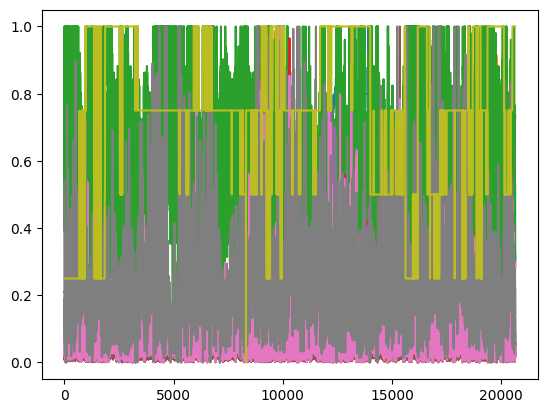

```python
plt.plot(normalized_housing)
```